# Data Retrieving from APIs

```python
import requests
```

```python
#Setting up urls
url_france = 'https://disease.sh/v3/covid-19/historical/France?lastdays=all'
url_italy = 'https://disease.sh/v3/covid-19/historical/Italy?lastdays=all'

#Sending GET requests
resp_f = requests.get(url_france)
resp_i = requests.get(url_italy)

#Checking for HTTP errors
resp_f.raise_for_status
resp_i.raise_for_status

#Getting data
df_france = resp_f.json()
df_italy = resp_i.json()
```

# Data retrieving from .json file

```python
import json
import numpy as np
import pandas as pd
import matplotlib.pyplot as plt
import seaborn as sns
```

```python
#Italy data
italy = json.load(open(r'C:\Users\39327\Desktop\Uni\Magistrale\Corsi SDS\Programming for Data Science\Python Project\data\Italy.json'))
italy_df = pd.DataFrame(italy['timeline'], columns = ['cases', 'deaths', 'recovered']) #to pandas df
italy_df.index.name = 'Date'

#France data
france = json.load(open(r'C:\Users\39327\Desktop\Uni\Magistrale\Corsi SDS\Programming for Data Science\Python Project\data\France.json'))
france_df = pd.DataFrame(france['timeline'], columns = ['cases', 'deaths', 'recovered']) #to pandas df
france_df.index.name = 'Date'
```

# Data Cleaning and Preprocessing

```python
#Italy
italy_df.sort_values(['cases', 'deaths', 'recovered']) #data are sorted right
italy_df.index.is_unique #the indexes are unique
italy_df.isnull().any() #there are not NULL values in the data frame
np.isnan(italy_df).any() #there are not NaN values in the data frame
```

```
cases        False
deaths       False
recovered    False
dtype: bool
```

```python
#France
france_df.sort_values(['cases', 'deaths', 'recovered']) #data are sorted right
france_df.index.is_unique #the indexes are unique
france_df.isnull().any() #there are not NULL values in the data frame
np.isnan(france_df).any() #there are not NaN values in the data frame
```

```
cases        False
deaths       False
recovered    False
dtype: bool
```

# Proportion of cases over total population

We now want to graphically see the proportion of the population that contracted COVID-19 in Italy and France.

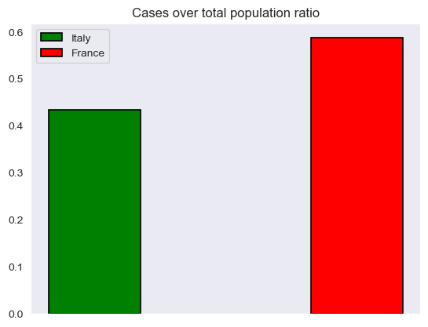

```python
#Creating the variables we need for the plot
total_c_it = italy_df['cases'].max()
total_c_fr = france_df['cases'].max()
italy_pop = 59110000
france_pop = 67750000
prop_it = total_c_it/italy_pop
prop_fr = total_c_fr/france_pop
x = ['Italy', 'France']
height = [prop_it, prop_fr]

#Plotting:
fig = plt.figure()
ax = fig.add_subplot()
ax.bar(x, height, width = .35, color = ['green', 'red'], label = ['Italy', 'France'],
       edgecolor = ['black', 'black'], linewidth = 1.2)
ax.set_title('Cases over total population ratio')
ax.grid(False)
ax.set_xticks([])
ax.legend()
plot.legend(shadow = True)
```

We notice that in France the proportion of cases was higher than the one in Italy

# Temporal Trends Analysis

The following is a weekly analysis of cases, deaths and recovered

```python
#Computing a dataframe which contains the weekly mean of cases, deaths and recoveries to check for
#significative variations of them

#For Italy:
columns = [0, 1, 2]
mean_variation_it = pd.DataFrame(columns = columns)
for names in columns:
    weeks = []
    i = 0
    j = 7
    counter = 0
    while j <= italy_df.shape[0]:
        weeks.insert(counter, italy_df.iloc[i:j, names].mean())
        i += 7
        j += 7
        counter += 1
    mean_variation_it[names] = weeks

#Rename columns:
mean_variation_it.columns = ['cases', 'deaths', 'recovered']

#For France:
columns = [0, 1, 2]
mean_variation_fr = pd.DataFrame(columns = columns)
for names in columns:
    weeks = []
    i = 0
    j = 7
    counter = 0
    while j <= italy_df.shape[0]:
        weeks.insert(counter, france_df.iloc[i:j, names].mean())
        i += 7
        j += 7
        counter += 1
    mean_variation_fr[names] = weeks
#print(weeks)

#Rename columns:
mean_variation_fr.columns = ['cases', 'deaths', 'recovered']
```

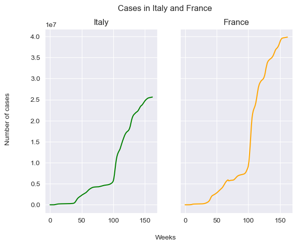

```python
#Plotting the cases results
fig1, ax1 = plt.subplots(1, 2, sharex = True, sharey = True) #creating figure and axes
ax1[0].plot(mean_variation_it['cases'], color = 'green') #plots
ax1[1].plot(mean_variation_fr['cases'], color = 'orange')
ax1[0].title.set_text('Italy') #titles
ax1[1].title.set_text('France')
fig1.suptitle('Cases in Italy and France') #main title
fig1.text(.47, 0, 'Weeks') #main x label
fig1.text(0, .4, 'Number of cases', rotation = 'vertical') #main y label
```

We can see that in both countries the cases growth is almost exponential, especially, after the 100th week, the situation degenerates. We can also notice from the above plots that there are less cases in Italy rather than in France.

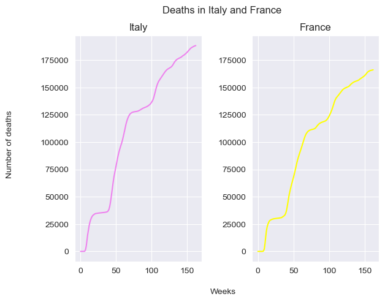

```python
#Plotting the deaths results
fig2 = plt.figure() #creating figure and axes
ax1 = fig2.add_subplot(1, 2, 1)
ax2 = fig2.add_subplot(1, 2, 2, sharex = ax1, sharey = ax1)
ax1.plot(mean_variation_it['deaths'], color = 'violet') #plotting
ax2.plot(mean_variation_fr['deaths'], color = 'yellow')
ax1.title.set_text('Italy') #titles
ax2.title.set_text('France')
fig2.suptitle('Deaths in Italy and France') #main title
fig2.text(.47, 0, 'Weeks') #main x label
fig2.text(-.05, .4, 'Number of deaths', rotation = 'vertical') #main y label
fig2.subplots_adjust(wspace = .4) #adjusting distance
ax1.set_xticks([0, 50, 100, 150]) #it is enough to set it for one plot since sharex is true
```

[output not shown]

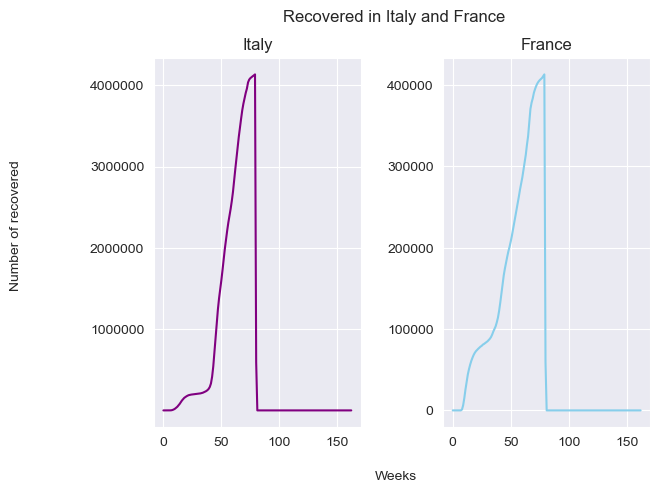

```python
#Plotting the recovered results
fig3, ax3 = plt.subplots(1, 2, sharex = True) #creating figure and axes
ax3[0].plot(mean_variation_it['recovered'], color = 'purple') #plots
ax3[1].plot(mean_variation_fr['recovered'], color = 'skyblue')
ax3[0].title.set_text('Italy') #titles
ax3[1].title.set_text('France')
fig3.suptitle('Recovered in Italy and France') #main title
fig3.text(.47, 0, 'Weeks') #main x label
fig3.text(-.1, .4, 'Number of recovered', rotation = 'vertical') #main y label
fig3.subplots_adjust(wspace = .4) #adjusting distance
ax3[0].set_xticks([0, 50, 100, 150]) #it is enough to set it for one plot since sharex is true
ax3[0].set_yticks([1000000, 2000000, 3000000, 4000000]) #set y ticks and labels for italy plot; we did
ax3[0].set_yticklabels([1000000, 2000000, 3000000, 4000000]) #this to remove the 1e notation
```

The number of recoveries in Italy is about 4 million, while in France is 400'000, notice that the data retrieve for both countries stop around the same period, before the 100th week

# Days of the week: cumulative cases, deaths and recovered.

```python
import datetime
```

```python
#Getting weekdays (Sunday is 0)
weekday = []

for i in range(italy_df.shape[0]):
    str_to_date = datetime.datetime.strptime(italy_df.index[i], '%m/%d/%y').date() #from str to datetime.date
    weekday.append(str_to_date.weekday()) #from datetime.date to weekday
#print(weekday)

#Attach this list to the dataframes
italy_df['weekday'] = weekday
france_df['weekday'] = weekday
```

```python
#Creating a dataframe with total cases, deaths and recovered for each day
#Italy
total_cases = []
total_deaths = []
total_recovered = []

for j in range(7):
    total_cases.append(italy_df.loc[italy_df['weekday'] == j, 'cases'].mean())
    total_deaths.append(italy_df.loc[italy_df['weekday'] == j, 'deaths'].mean())
    total_recovered.append(italy_df.loc[italy_df['weekday'] == j, 'recovered'].mean())
total_cases = np.array(total_cases)
total_deaths = np.array(total_deaths)
total_recovered = np.array(total_recovered)
dict_it = {'weekday': np.arange(7), 'total_cases': total_cases, 'total_deaths': total_deaths,
           'total_recovered': total_recovered}
days_df_it = pd.DataFrame(dict_it)
days_df_it['weekday'] = days_df_it['weekday'].astype('category')
days_df_it['weekday'] = ['Sunday', 'Monday', 'Tuesday', 'Wednesday', 'Thursday', 'Friday', 'Saturday']

#France
total_cases = []
total_deaths = []
total_recovered = []

for j in range(7):
    total_cases.append(france_df.loc[france_df['weekday'] == j, 'cases'].mean())
    total_deaths.append(france_df.loc[france_df['weekday'] == j, 'deaths'].mean())
    total_recovered.append(france_df.loc[france_df['weekday'] == j, 'recovered'].mean())
total_cases = np.array(total_cases)
total_deaths = np.array(total_deaths)
total_recovered = np.array(total_recovered)
dict_fr = {'weekday': np.arange(7), 'total_cases': total_cases, 'total_deaths': total_deaths,
           'total_recovered': total_recovered}
days_df_fr = pd.DataFrame(dict_fr)
days_df_fr['weekday'] = days_df_fr['weekday'].astype('category')
days_df_fr['weekday'] = ['Sunday', 'Monday', 'Tuesday', 'Wednesday', 'Thursday', 'Friday', 'Saturday']
days_df_fr
```

|  | weekday | total_cases | total_deaths | total_recovered |
| --- | --- | --- | --- | --- |
| 0 | Sunday | 1.409868e+07 | 99342.914110 | 84803.079755 |
| 1 | Monday | 1.414687e+07 | 99569.631902 | 85280.815951 |
| 2 | Tuesday | 1.410325e+07 | 99105.701220 | 85182.817073 |
| 3 | Wednesday | 1.414245e+07 | 99245.365854 | 83086.432927 |
| 4 | Thursday | 1.402213e+07 | 99021.245399 | 83998.466258 |
| 5 | Friday | 1.405002e+07 | 99103.257669 | 84221.846626 |
| 6 | Saturday | 1.407259e+07 | 99164.067485 | 84458.852761 |

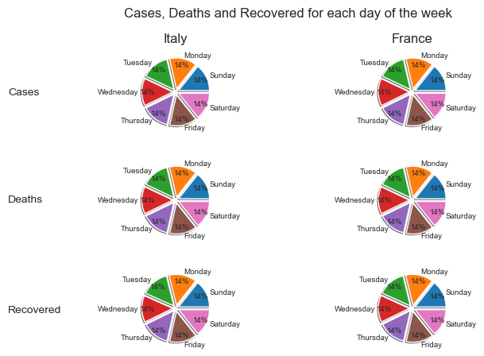

```python
#Plotting the results
fig_pies, ax_pies = plt.subplots(3, 2)
ax_pies[0, 0].pie(x = days_df_it['total_cases'], labels = days_df_it['weekday'], autopct = '%1.0f%%',
        pctdistance = .8, shadow = True, explode = [.1, .1, .1, .1, .1, .1, .1],
        textprops = {'fontsize': 7})
ax_pies[0, 1].pie(x = days_df_fr['total_cases'], labels = days_df_fr['weekday'], autopct = '%1.0f%%',
        pctdistance = .8, shadow = True, explode = [.1, .1, .1, .1, .1, .1, .1],
        textprops = {'fontsize': 7})
ax_pies[1, 0].pie(x = days_df_it['total_deaths'], labels = days_df_it['weekday'], autopct = '%1.0f%%',
        pctdistance = .8, shadow = True, explode = [.1, .1, .1, .1, .1, .1, .1],
        textprops = {'fontsize': 7})
ax_pies[1, 1].pie(x = days_df_fr['total_deaths'], labels = days_df_fr['weekday'], autopct = '%1.0f%%',
        pctdistance = .8, shadow = True, explode = [.1, .1, .1, .1, .1, .1, .1],
        textprops = {'fontsize': 7})
ax_pies[2, 0].pie(x = days_df_it['total_recovered'], labels = days_df_it['weekday'], autopct = '%1.0f%%',
        pctdistance = .8, shadow = True, explode = [.1, .1, .1, .1, .1, .1, .1],
        textprops = {'fontsize': 7})
ax_pies[2, 1].pie(x = days_df_fr['total_recovered'], labels = days_df_fr['weekday'], autopct = '%1.0f%%',
        pctdistance = .8, shadow = True, explode = [.1, .1, .1, .1, .1, .1, .1],
        textprops = {'fontsize': 7})

fig_pies.suptitle('Cases, Deaths and Recovered for each day of the week', y = 1) #main title
ax_pies[0, 0].set_title('Italy', y = 1.05) #titles
ax_pies[0, 1].set_title('France', y = 1.05)
fig_pies.text(-.05, .77, 'Cases') #texts
fig_pies.text(-.05, .49, 'Deaths')
fig_pies.text(-.05, .2, 'Recovered')
fig_pies.subplots_adjust(wspace = .5, hspace = .4) #adjust distance between plots
```

We created a new column with the day of the week in order to look for particular days in which there were different variation from the mean in cases, deaths or recovered. But, as we can see from the pie chart above, the distribution seems almost uniform.

# Days of the week: cases, deaths and recoveries

From the cumulative dataframe we compute a new one which contains daily cases, deaths and recoveries. Then, we do the same plot we have already done above.

```python
#Computing the daily cases and deaths
#Italy:
daily_cases = []
daily_deaths = []
daily_recovered = []
for i in range((italy_df.shape[0] - 1)):
    daily_cases.append(italy_df.cases[i + 1] - italy_df.cases[i])
    daily_deaths.append(italy_df.deaths[i + 1] - italy_df.deaths[i])
    daily_recovered.append(italy_df.recovered[i + 1] - italy_df.recovered[i])

daily_df_dict = {'d_cases': daily_cases, 'd_deaths': daily_deaths, 'd_recovered': daily_recovered}
daily_df_it = pd.DataFrame(daily_df_dict)

daily_df_it['weekday'] = weekday[1:] #attaching weekdays

#France:
daily_cases = []
daily_deaths = []
daily_recovered = []
for i in range((france_df.shape[0] - 1)):
    daily_cases.append(france_df.cases[i + 1] - france_df.cases[i])
    daily_deaths.append(france_df.deaths[i + 1] - france_df.deaths[i])
    daily_recovered.append(france_df.recovered[i + 1] - france_df.recovered[i])

daily_df_dict = {'d_cases': daily_cases, 'd_deaths': daily_deaths, 'd_recovered': daily_recovered}
daily_df_fr = pd.DataFrame(daily_df_dict)

daily_df_fr['weekday'] = weekday[1:] #attaching weekdays
```

```python
#Summing the results for each day:
#Italy
total_cases = []
total_deaths = []
total_recovered = []

for j in range(7):
    total_cases.append(daily_df_it.loc[daily_df_it['weekday'] == j, 'd_cases'].sum())
    total_deaths.append(daily_df_it.loc[daily_df_it['weekday'] == j, 'd_deaths'].sum())
    total_recovered.append(daily_df_it.loc[daily_df_it['weekday'] == j, 'd_recovered'].sum())
total_cases = np.array(total_cases)
total_deaths = np.array(total_deaths)
total_recovered = np.array(total_recovered)
dict_it = {'weekday': np.arange(7), 'total_cases': total_cases, 'total_deaths': total_deaths,
           'total_recovered': total_recovered}
days_df_it = pd.DataFrame(dict_it)
days_df_it['weekday'] = days_df_it['weekday'].astype('category')
days_df_it['weekday'] = ['Sunday', 'Monday', 'Tuesday', 'Wednesday', 'Thursday', 'Friday', 'Saturday']

#France
total_cases = []
total_deaths = []
total_recovered = []

for j in range(7):
    total_cases.append(daily_df_fr.loc[daily_df_fr['weekday'] == j, 'd_cases'].sum())
    total_deaths.append(daily_df_fr.loc[daily_df_fr['weekday'] == j, 'd_deaths'].sum())
    total_recovered.append(daily_df_fr.loc[daily_df_fr['weekday'] == j, 'd_recovered'].sum())
total_cases = np.array(total_cases)
total_deaths = np.array(total_deaths)
total_recovered = np.array(total_recovered)
dict_fr = {'weekday': np.arange(7), 'total_cases': total_cases, 'total_deaths': total_deaths,
           'total_recovered': total_recovered}
days_df_fr = pd.DataFrame(dict_fr)
days_df_fr['weekday'] = days_df_fr['weekday'].astype('category')
days_df_fr['weekday'] = ['Sunday', 'Monday', 'Tuesday', 'Wednesday', 'Thursday', 'Friday', 'Saturday']

print('Italy:', days_df_it)
print('France:', days_df_fr)
```

```
Italy:      weekday  total_cases  total_deaths  total_recovered
0     Sunday      1773394         22323           528452
1     Monday      4062562         30218           671407
2    Tuesday      3800916         27789           706263
3  Wednesday      3833196         27895         -3518947
4   Thursday      5691620         36946           641438
5     Friday      3583569         24717           556143
6   Saturday      2858253         18434           415244
France:      weekday  total_cases  total_deaths  total_recovered
0     Sunday      4252404         29152            56109
1     Monday      7854990         36955            77871
2    Tuesday      6993360         23485            69209
3  Wednesday      6428410         22905          -343807
4   Thursday      6112763         30399            65575
5     Friday      4544938         13368            36411
6   Saturday      3679853          9912            38632
```

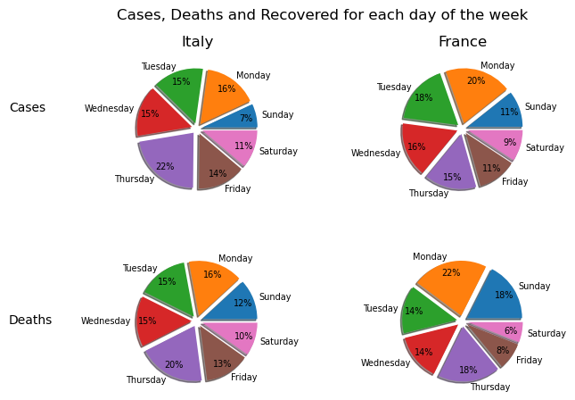

```python
#We take the absolute value of the two data frames because there are negative values
#days_df_it['total_recovered'] = abs(days_df_it['total_recovered'])
#days_df_fr['total_recovered'] = abs(days_df_fr['total_recovered'])

#Plotting the results:
plt.style.use('default')
fig_pies, ax_pies = plt.subplots(2, 2)
ax_pies[0, 0].pie(x = days_df_it['total_cases'], labels = days_df_it['weekday'], autopct = '%1.0f%%',
        pctdistance = .8, shadow = True, explode = [.1, .1, .1, .1, .1, .1, .1],
        textprops = {'fontsize': 7})
ax_pies[0, 1].pie(x = days_df_fr['total_cases'], labels = days_df_fr['weekday'], autopct = '%1.0f%%',
        pctdistance = .8, shadow = True, explode = [.1, .1, .1, .1, .1, .1, .1],
        textprops = {'fontsize': 7})
ax_pies[1, 0].pie(x = days_df_it['total_deaths'], labels = days_df_it['weekday'], autopct = '%1.0f%%',
        pctdistance = .8, shadow = True, explode = [.1, .1, .1, .1, .1, .1, .1],
        textprops = {'fontsize': 7})
ax_pies[1, 1].pie(x = days_df_fr['total_deaths'], labels = days_df_fr['weekday'], autopct = '%1.0f%%',
        pctdistance = .8, shadow = True, explode = [.1, .1, .1, .1, .1, .1, .1],
        textprops = {'fontsize': 7})
#ax_pies[2, 0].pie(x = days_df_it['total_recovered'], labels = days_df_it['weekday'], autopct = '%1.0f%%',
        #pctdistance = .8, shadow = True, explode = [.1, .1, .1, .1, .1, .1, .1],
        #textprops = {'fontsize': 7})
#ax_pies[2, 1].pie(x = days_df_fr['total_recovered'], labels = days_df_fr['weekday'], autopct = '%1.0f%%',
        #pctdistance = .8, shadow = True, explode = [.1, .1, .1, .1, .1, .1, .1],
        #textprops = {'fontsize': 7})

fig_pies.suptitle('Cases, Deaths and Recovered for each day of the week', y = 1) #main title
ax_pies[0, 0].set_title('Italy', y = 1.05) #titles
ax_pies[0, 1].set_title('France', y = 1.05)
fig_pies.text(-.05, .76, 'Cases') #texts
#fig_pies.text(-.05, .49, 'Deaths')
fig_pies.text(-.05, .265, 'Deaths')
fig_pies.subplots_adjust(wspace = .5, hspace = .4) #adjust distance between plots
```

# General trend analysis

```python
#Merging the data frames
france_df = france_df.drop('weekday', axis = 'columns') #remove weekday from one of the two data frames
merged_df = pd.concat([italy_df, france_df], axis = 1, join = 'inner')
merged_df.columns = ['cases_it', 'deaths_it', 'recovered_it', 'weekday', 'cases_fr', 'deaths_fr',
                     'recovered_fr']
```

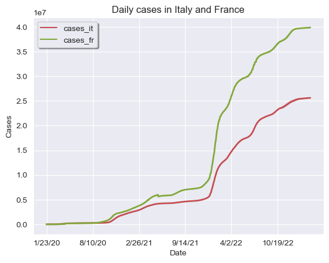

```python
#Plotting daily obs. for cases
sns.set_style('darkgrid')
plot = sns.lineplot(data = merged_df[['cases_it', 'cases_fr']], palette = ['r', 'g'],
                        linewidth = 2, dashes = False)
plot.set_xticks(np.arange(1, 1143, step = 200))
#plot.set_xticklabels(np.arange(1, 1143, step = 200))
plot.set_ylabel('Cases')
plot.set_title('Daily cases in Italy and France')
plot.legend(shadow = True)
```

As we can see the covid cases start slowly and reach a plateau around the end of 2022, before which there is an almost exponential grow. We can notice that the total cases in France are higher than in Italy.

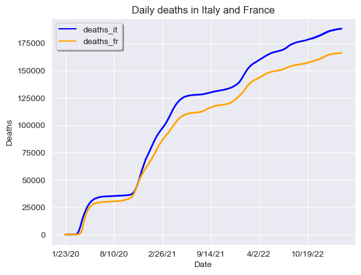

```python
#Plotting daily obs. for deaths
plot = sns.lineplot(data = merged_df[['deaths_it', 'deaths_fr']], palette = ['blue', 'orange'],
                        linewidth = 2, dashes = False)
plot.set_xticks(np.arange(1, 1143, step = 200))
#plot.set_xticklabels(np.arange(1, 1143, step = 200))
plot.set_ylabel('Deaths')
plot.set_title('Daily deaths in Italy and France')
plot.legend(shadow = True)
```

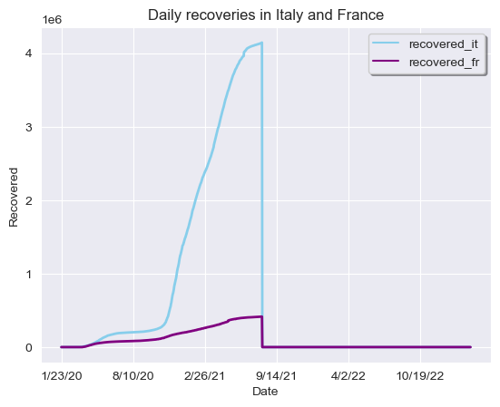

```python
#Plotting daily obs. for recovered
plot = sns.lineplot(data = merged_df[['recovered_it', 'recovered_fr']], palette = ['skyblue', 'purple'],
                        linewidth = 2, dashes = False)
plot.set_xticks(np.arange(1, 1143, step = 200))
#plot.set_xticklabels(np.arange(1, 1143, step = 200))
plot.set_ylabel('Recovered')
plot.set_title('Daily recoveries in Italy and France')
plot.legend(shadow = True)
```

We can again see that the recoveries are much more in Italy than in France.